# Credict Card fraud detection Machine Learning project

## Objective

1.The main objective of this project is to detect the how many fraud transactions are made by the customers. and

2.To choose the best model which gives the better accuaracy.

## Problem statement

In this project I am going to predict the fraud caused by the customers. As this is a classification problem we will be using Logistic Regression, knn, SVM, naive bayes, Random forest, decision models for model training and for predictions.

Imported various libraries like:

Numpy: numpy module is used to do the mathematical calculations

pandas:pandas is a software library written for the Python programming language for data manipulation and analysis.

seaborn:Seaborn is used for visualizations of data.

matplotlib: Matplotlib is used for ploting graphs and charts.

traintestsplit: Train test split is usd to split the data into training and testing part.

logistic regression, KNN,SVM, naive bayes, DecisionTree, RandomForestClassifier: This are algorithms which is used to bulit models.

accuracy Score, classification report, confusion matrix: This is used for model evaluation or to check the performance of the model.

## Variables information.

Imported dataset of credit card fraud detection, the variables in the dataset are:

Time, V1-V28,Amount,Class

Time: Time defines in how much time transaction is done.

V1-V28 : this is confidential data

Amount: How much amount is transacted

Class: Tells that the transaction is normal or fraud.

## importing important libraries

```python
import numpy as np
import pandas as pd
import seaborn as sns
import matplotlib.pyplot as plt
from sklearn.model_selection import train_test_split
from sklearn.metrics import accuracy_score, classification_report, confusion_matrix, precision_score,recall_score,f1_score
```

## importing dataset

```python
data = pd.read_csv("C:/Users/Gayatri/Downloads/archive (8)/creditcard.csv")
```

## data preprocessing

```python
data.head()
```

|  | Time | V1 | V2 | V3 | V4 | V5 | V6 | V7 | V8 | V9 | ... | V21 | V22 | V23 | V24 | V25 | V26 | V27 | V28 | Amount | Class |
| --- | --- | --- | --- | --- | --- | --- | --- | --- | --- | --- | --- | --- | --- | --- | --- | --- | --- | --- | --- | --- | --- |
| 0 | 0.0 | -1.359807 | -0.072781 | 2.536347 | 1.378155 | -0.338321 | 0.462388 | 0.239599 | 0.098698 | 0.363787 | ... | -0.018307 | 0.277838 | -0.110474 | 0.066928 | 0.128539 | -0.189115 | 0.133558 | -0.021053 | 149.62 | 0 |
| 1 | 0.0 | 1.191857 | 0.266151 | 0.166480 | 0.448154 | 0.060018 | -0.082361 | -0.078803 | 0.085102 | -0.255425 | ... | -0.225775 | -0.638672 | 0.101288 | -0.339846 | 0.167170 | 0.125895 | -0.008983 | 0.014724 | 2.69 | 0 |
| 2 | 1.0 | -1.358354 | -1.340163 | 1.773209 | 0.379780 | -0.503198 | 1.800499 | 0.791461 | 0.247676 | -1.514654 | ... | 0.247998 | 0.771679 | 0.909412 | -0.689281 | -0.327642 | -0.139097 | -0.055353 | -0.059752 | 378.66 | 0 |
| 3 | 1.0 | -0.966272 | -0.185226 | 1.792993 | -0.863291 | -0.010309 | 1.247203 | 0.237609 | 0.377436 | -1.387024 | ... | -0.108300 | 0.005274 | -0.190321 | -1.175575 | 0.647376 | -0.221929 | 0.062723 | 0.061458 | 123.50 | 0 |
| 4 | 2.0 | -1.158233 | 0.877737 | 1.548718 | 0.403034 | -0.407193 | 0.095921 | 0.592941 | -0.270533 | 0.817739 | ... | -0.009431 | 0.798278 | -0.137458 | 0.141267 | -0.206010 | 0.502292 | 0.219422 | 0.215153 | 69.99 | 0 |

5 rows × 31 columns

```python
data.tail()
```

|  | Time | V1 | V2 | V3 | V4 | V5 | V6 | V7 | V8 | V9 | ... | V21 | V22 | V23 | V24 | V25 | V26 | V27 | V28 | Amount | Class |
| --- | --- | --- | --- | --- | --- | --- | --- | --- | --- | --- | --- | --- | --- | --- | --- | --- | --- | --- | --- | --- | --- |
| 284802 | 172786.0 | -11.881118 | 10.071785 | -9.834783 | -2.066656 | -5.364473 | -2.606837 | -4.918215 | 7.305334 | 1.914428 | ... | 0.213454 | 0.111864 | 1.014480 | -0.509348 | 1.436807 | 0.250034 | 0.943651 | 0.823731 | 0.77 | 0 |
| 284803 | 172787.0 | -0.732789 | -0.055080 | 2.035030 | -0.738589 | 0.868229 | 1.058415 | 0.024330 | 0.294869 | 0.584800 | ... | 0.214205 | 0.924384 | 0.012463 | -1.016226 | -0.606624 | -0.395255 | 0.068472 | -0.053527 | 24.79 | 0 |
| 284804 | 172788.0 | 1.919565 | -0.301254 | -3.249640 | -0.557828 | 2.630515 | 3.031260 | -0.296827 | 0.708417 | 0.432454 | ... | 0.232045 | 0.578229 | -0.037501 | 0.640134 | 0.265745 | -0.087371 | 0.004455 | -0.026561 | 67.88 | 0 |
| 284805 | 172788.0 | -0.240440 | 0.530483 | 0.702510 | 0.689799 | -0.377961 | 0.623708 | -0.686180 | 0.679145 | 0.392087 | ... | 0.265245 | 0.800049 | -0.163298 | 0.123205 | -0.569159 | 0.546668 | 0.108821 | 0.104533 | 10.00 | 0 |
| 284806 | 172792.0 | -0.533413 | -0.189733 | 0.703337 | -0.506271 | -0.012546 | -0.649617 | 1.577006 | -0.414650 | 0.486180 | ... | 0.261057 | 0.643078 | 0.376777 | 0.008797 | -0.473649 | -0.818267 | -0.002415 | 0.013649 | 217.00 | 0 |

5 rows × 31 columns

```python
data["Class"].value_counts()
```

```
0    284315
1       492
Name: Class, dtype: int64
```

```python
data.isna().sum()
```

```
Time      0
V1        0
V2        0
V3        0
V4        0
V5        0
V6        0
V7        0
V8        0
V9        0
V10       0
V11       0
V12       0
V13       0
V14       0
V15       0
V16       0
V17       0
V18       0
V19       0
V20       0
V21       0
V22       0
V23       0
V24       0
V25       0
V26       0
V27       0
V28       0
Amount    0
Class     0
dtype: int64
```

This observation tells that there is no null values present in the dataset. The data is clean to perform the rest of the operations.

```python
data.describe()
```

|  | Time | V1 | V2 | V3 | V4 | V5 | V6 | V7 | V8 | V9 | ... | V21 | V22 | V23 | V24 | V25 | V26 | V27 | V28 | Amount | Class |
| --- | --- | --- | --- | --- | --- | --- | --- | --- | --- | --- | --- | --- | --- | --- | --- | --- | --- | --- | --- | --- | --- |
| count | 284807.000000 | 2.848070e+05 | 2.848070e+05 | 2.848070e+05 | 2.848070e+05 | 2.848070e+05 | 2.848070e+05 | 2.848070e+05 | 2.848070e+05 | 2.848070e+05 | ... | 2.848070e+05 | 2.848070e+05 | 2.848070e+05 | 2.848070e+05 | 2.848070e+05 | 2.848070e+05 | 2.848070e+05 | 2.848070e+05 | 284807.000000 | 284807.000000 |
| mean | 94813.859575 | 1.168375e-15 | 3.416908e-16 | -1.379537e-15 | 2.074095e-15 | 9.604066e-16 | 1.487313e-15 | -5.556467e-16 | 1.213481e-16 | -2.406331e-15 | ... | 1.654067e-16 | -3.568593e-16 | 2.578648e-16 | 4.473266e-15 | 5.340915e-16 | 1.683437e-15 | -3.660091e-16 | -1.227390e-16 | 88.349619 | 0.001727 |
| std | 47488.145955 | 1.958696e+00 | 1.651309e+00 | 1.516255e+00 | 1.415869e+00 | 1.380247e+00 | 1.332271e+00 | 1.237094e+00 | 1.194353e+00 | 1.098632e+00 | ... | 7.345240e-01 | 7.257016e-01 | 6.244603e-01 | 6.056471e-01 | 5.212781e-01 | 4.822270e-01 | 4.036325e-01 | 3.300833e-01 | 250.120109 | 0.041527 |
| min | 0.000000 | -5.640751e+01 | -7.271573e+01 | -4.832559e+01 | -5.683171e+00 | -1.137433e+02 | -2.616051e+01 | -4.355724e+01 | -7.321672e+01 | -1.343407e+01 | ... | -3.483038e+01 | -1.093314e+01 | -4.480774e+01 | -2.836627e+00 | -1.029540e+01 | -2.604551e+00 | -2.256568e+01 | -1.543008e+01 | 0.000000 | 0.000000 |
| 25% | 54201.500000 | -9.203734e-01 | -5.985499e-01 | -8.903648e-01 | -8.486401e-01 | -6.915971e-01 | -7.682956e-01 | -5.540759e-01 | -2.086297e-01 | -6.430976e-01 | ... | -2.283949e-01 | -5.423504e-01 | -1.618463e-01 | -3.545861e-01 | -3.171451e-01 | -3.269839e-01 | -7.083953e-02 | -5.295979e-02 | 5.600000 | 0.000000 |
| 50% | 84692.000000 | 1.810880e-02 | 6.548556e-02 | 1.798463e-01 | -1.984653e-02 | -5.433583e-02 | -2.741871e-01 | 4.010308e-02 | 2.235804e-02 | -5.142873e-02 | ... | -2.945017e-02 | 6.781943e-03 | -1.119293e-02 | 4.097606e-02 | 1.659350e-02 | -5.213911e-02 | 1.342146e-03 | 1.124383e-02 | 22.000000 | 0.000000 |
| 75% | 139320.500000 | 1.315642e+00 | 8.037239e-01 | 1.027196e+00 | 7.433413e-01 | 6.119264e-01 | 3.985649e-01 | 5.704361e-01 | 3.273459e-01 | 5.971390e-01 | ... | 1.863772e-01 | 5.285536e-01 | 1.476421e-01 | 4.395266e-01 | 3.507156e-01 | 2.409522e-01 | 9.104512e-02 | 7.827995e-02 | 77.165000 | 0.000000 |
| max | 172792.000000 | 2.454930e+00 | 2.205773e+01 | 9.382558e+00 | 1.687534e+01 | 3.480167e+01 | 7.330163e+01 | 1.205895e+02 | 2.000721e+01 | 1.559499e+01 | ... | 2.720284e+01 | 1.050309e+01 | 2.252841e+01 | 4.584549e+00 | 7.519589e+00 | 3.517346e+00 | 3.161220e+01 | 3.384781e+01 | 25691.160000 | 1.000000 |

8 rows × 31 columns

By using describe method we get the count,mean,standard,minimum value interquartile ranges from 25 to 75 and maximum value of the each and every attribute.

```python
data.info()
```

```
<class 'pandas.core.frame.DataFrame'>
RangeIndex: 284807 entries, 0 to 284806
Data columns (total 31 columns):
 #   Column  Non-Null Count   Dtype
---  ------  --------------   -----
 0   Time    284807 non-null  float64
 1   V1      284807 non-null  float64
 2   V2      284807 non-null  float64
 3   V3      284807 non-null  float64
 4   V4      284807 non-null  float64
 5   V5      284807 non-null  float64
 6   V6      284807 non-null  float64
 7   V7      284807 non-null  float64
 8   V8      284807 non-null  float64
 9   V9      284807 non-null  float64
```

[output cut: 23 more lines]

By using info() method we can see that all of the data variables have same data type which is float64 but class is of integer data type.

### 0 - Normal transaction

### 1 - fraud transaction

```python
real = data[data["Class"] == 0]
fraud = data[data["Class"] == 1]
```

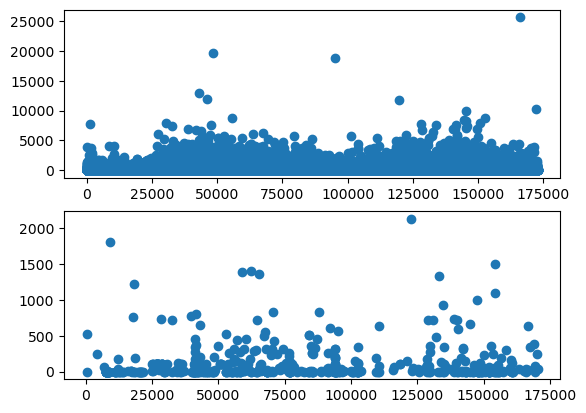

```python
plt.subplot(2,1,1)
plt.scatter(x = real.Time,y =  real.Amount)
plt.subplot(2,1,2)
plt.scatter(x = fraud.Time, y = fraud.Amount)
```

```python
print(real.shape)
print(fraud.shape)
```

```
(284315, 31)
(492, 31)
```

```python
real.Amount.describe()
```

```
count    284315.000000
mean         88.291022
std         250.105092
min           0.000000
25%           5.650000
50%          22.000000
75%          77.050000
max       25691.160000
Name: Amount, dtype: float64
```

```python
fraud.Amount.describe()
```

```
count     492.000000
mean      122.211321
std       256.683288
min         0.000000
25%         1.000000
50%         9.250000
75%       105.890000
max      2125.870000
Name: Amount, dtype: float64
```

### Under sampling

Build a sample dataset containing similar distribution of normal and fraud trnsaction

Number of fraud transaction -- 492

```python
from sklearn.utils import resample
real_sample = real.sample(n = 492)
```

Concatenating two dataframe

```python
new_data = pd.concat([real_sample,fraud],axis = 0)
```

```python
new_data.head()
```

|  | Time | V1 | V2 | V3 | V4 | V5 | V6 | V7 | V8 | V9 | ... | V21 | V22 | V23 | V24 | V25 | V26 | V27 | V28 | Amount | Class |
| --- | --- | --- | --- | --- | --- | --- | --- | --- | --- | --- | --- | --- | --- | --- | --- | --- | --- | --- | --- | --- | --- |
| 145680 | 87125.0 | -1.103340 | 0.702394 | -1.100975 | -2.494209 | 1.103053 | -2.097877 | 1.608394 | -0.421520 | 0.913303 | ... | -0.002806 | 0.787495 | 0.070577 | -0.028882 | -0.200344 | 0.518187 | 0.190252 | -0.199114 | 1.00 | 0 |
| 60971 | 49589.0 | 1.223422 | 0.309144 | 0.727424 | 1.110498 | -0.505360 | -0.750576 | -0.054292 | -0.137881 | 0.139040 | ... | -0.075431 | -0.168895 | 0.028876 | 0.374569 | 0.434326 | -0.495462 | 0.038642 | 0.031752 | 1.00 | 0 |
| 268933 | 163454.0 | -1.649103 | 1.567169 | -1.588127 | -0.357308 | 0.074773 | -1.626656 | 0.381221 | 0.495446 | -0.198530 | ... | 0.416295 | 1.260807 | 0.213770 | -0.002556 | -0.708195 | -0.369980 | -0.679177 | -0.201218 | 29.00 | 0 |
| 131611 | 79666.0 | 1.243429 | 0.132585 | -0.158441 | -0.022295 | 0.000163 | -0.959618 | 0.466414 | -0.373753 | -0.246144 | ... | -0.433325 | -1.344319 | 0.082412 | -0.092016 | 0.200669 | 0.645422 | -0.102101 | 0.009956 | 56.94 | 0 |
| 150900 | 94094.0 | -0.476083 | 1.773989 | 2.127627 | 4.507577 | -0.224429 | 1.529165 | -0.698580 | 0.783828 | -0.534456 | ... | -0.004039 | 0.414630 | -0.007649 | -0.385324 | -0.855408 | 0.207048 | 0.360077 | 0.191967 | 0.00 | 0 |

5 rows × 31 columns

```python
new_data.tail()
```

|  | Time | V1 | V2 | V3 | V4 | V5 | V6 | V7 | V8 | V9 | ... | V21 | V22 | V23 | V24 | V25 | V26 | V27 | V28 | Amount | Class |
| --- | --- | --- | --- | --- | --- | --- | --- | --- | --- | --- | --- | --- | --- | --- | --- | --- | --- | --- | --- | --- | --- |
| 279863 | 169142.0 | -1.927883 | 1.125653 | -4.518331 | 1.749293 | -1.566487 | -2.010494 | -0.882850 | 0.697211 | -2.064945 | ... | 0.778584 | -0.319189 | 0.639419 | -0.294885 | 0.537503 | 0.788395 | 0.292680 | 0.147968 | 390.00 | 1 |
| 280143 | 169347.0 | 1.378559 | 1.289381 | -5.004247 | 1.411850 | 0.442581 | -1.326536 | -1.413170 | 0.248525 | -1.127396 | ... | 0.370612 | 0.028234 | -0.145640 | -0.081049 | 0.521875 | 0.739467 | 0.389152 | 0.186637 | 0.76 | 1 |
| 280149 | 169351.0 | -0.676143 | 1.126366 | -2.213700 | 0.468308 | -1.120541 | -0.003346 | -2.234739 | 1.210158 | -0.652250 | ... | 0.751826 | 0.834108 | 0.190944 | 0.032070 | -0.739695 | 0.471111 | 0.385107 | 0.194361 | 77.89 | 1 |
| 281144 | 169966.0 | -3.113832 | 0.585864 | -5.399730 | 1.817092 | -0.840618 | -2.943548 | -2.208002 | 1.058733 | -1.632333 | ... | 0.583276 | -0.269209 | -0.456108 | -0.183659 | -0.328168 | 0.606116 | 0.884876 | -0.253700 | 245.00 | 1 |
| 281674 | 170348.0 | 1.991976 | 0.158476 | -2.583441 | 0.408670 | 1.151147 | -0.096695 | 0.223050 | -0.068384 | 0.577829 | ... | -0.164350 | -0.295135 | -0.072173 | -0.450261 | 0.313267 | -0.289617 | 0.002988 | -0.015309 | 42.53 | 1 |

5 rows × 31 columns

```python
new_data["Class"].value_counts()
```

```
0    492
1    492
Name: Class, dtype: int64
```

```python
new_data.groupby("Class").mean()
```

| Class | Time | V1 | V2 | V3 | V4 | V5 | V6 | V7 | V8 | V9 | ... | V20 | V21 | V22 | V23 | V24 | V25 | V26 | V27 | V28 | Amount |
| --- | --- | --- | --- | --- | --- | --- | --- | --- | --- | --- | --- | --- | --- | --- | --- | --- | --- | --- | --- | --- | --- |
| 0 | 93870.020325 | -0.089876 | 0.010097 | 0.118938 | 0.125459 | 0.130388 | 0.013560 | 0.018855 | -0.018249 | -0.027505 | ... | 0.008247 | 0.051017 | 0.048169 | -0.011407 | 0.040764 | -0.053530 | -0.039687 | -0.012425 | 0.008838 | 89.201382 |
| 1 | 80746.806911 | -4.771948 | 3.623778 | -7.033281 | 4.542029 | -3.151225 | -1.397737 | -5.568731 | 0.570636 | -2.581123 | ... | 0.372319 | 0.713588 | 0.014049 | -0.040308 | -0.105130 | 0.041449 | 0.051648 | 0.170575 | 0.075667 | 122.211321 |

2 rows × 30 columns

## EDA

```python
corr = data.corr()
corr
```

|  | Time | V1 | V2 | V3 | V4 | V5 | V6 | V7 | V8 | V9 | ... | V21 | V22 | V23 | V24 | V25 | V26 | V27 | V28 | Amount | Class |
| --- | --- | --- | --- | --- | --- | --- | --- | --- | --- | --- | --- | --- | --- | --- | --- | --- | --- | --- | --- | --- | --- |
| Time | 1.000000 | 1.173963e-01 | -1.059333e-02 | -4.196182e-01 | -1.052602e-01 | 1.730721e-01 | -6.301647e-02 | 8.471437e-02 | -3.694943e-02 | -8.660434e-03 | ... | 4.473573e-02 | 1.440591e-01 | 5.114236e-02 | -1.618187e-02 | -2.330828e-01 | -4.140710e-02 | -5.134591e-03 | -9.412688e-03 | -0.010596 | -0.012323 |
| V1 | 0.117396 | 1.000000e+00 | 4.135835e-16 | -1.227819e-15 | -9.215150e-16 | 1.812612e-17 | -6.506567e-16 | -1.005191e-15 | -2.433822e-16 | -1.513678e-16 | ... | -2.457409e-16 | -4.290944e-16 | 6.168652e-16 | -4.425156e-17 | -9.605737e-16 | -1.581290e-17 | 1.198124e-16 | 2.083082e-15 | -0.227709 | -0.101347 |
| V2 | -0.010593 | 4.135835e-16 | 1.000000e+00 | 3.243764e-16 | -1.121065e-15 | 5.157519e-16 | 2.787346e-16 | 2.055934e-16 | -5.377041e-17 | 1.978488e-17 | ... | -8.480447e-17 | 1.526333e-16 | 1.634231e-16 | 1.247925e-17 | -4.478846e-16 | 2.057310e-16 | -4.966953e-16 | -5.093836e-16 | -0.531409 | 0.091289 |
| V3 | -0.419618 | -1.227819e-15 | 3.243764e-16 | 1.000000e+00 | 4.711293e-16 | -6.539009e-17 | 1.627627e-15 | 4.895305e-16 | -1.268779e-15 | 5.568367e-16 | ... | 5.706192e-17 | -1.133902e-15 | -4.983035e-16 | 2.686834e-19 | -1.104734e-15 | -1.238062e-16 | 1.045747e-15 | 9.775546e-16 | -0.210880 | -0.192961 |
| V4 | -0.105260 | -9.215150e-16 | -1.121065e-15 | 4.711293e-16 | 1.000000e+00 | -1.719944e-15 | -7.491959e-16 | -4.104503e-16 | 5.697192e-16 | 6.923247e-16 | ... | -1.949553e-16 | -6.276051e-17 | 9.164206e-17 | 1.584638e-16 | 6.070716e-16 | -4.247268e-16 | 3.977061e-17 | -2.761403e-18 | 0.098732 | 0.133447 |
| V5 | 0.173072 | 1.812612e-17 | 5.157519e-16 | -6.539009e-17 | -1.719944e-15 | 1.000000e+00 | 2.408382e-16 | 2.715541e-16 | 7.437229e-16 | 7.391702e-16 | ... | -3.920976e-16 | 1.253751e-16 | -8.428683e-18 | -1.149255e-15 | 4.808532e-16 | 4.319541e-16 | 6.590482e-16 | -5.613951e-18 | -0.386356 | -0.094974 |
| V6 | -0.063016 | -6.506567e-16 | 2.787346e-16 | 1.627627e-15 | -7.491959e-16 | 2.408382e-16 | 1.000000e+00 | 1.191668e-16 | -1.104219e-16 | 4.131207e-16 | ... | 5.833316e-17 | -4.705235e-19 | 1.046712e-16 | -1.071589e-15 | 4.562861e-16 | -1.357067e-16 | -4.452461e-16 | 2.594754e-16 | 0.215981 | -0.043643 |
| V7 | 0.084714 | -1.005191e-15 | 2.055934e-16 | 4.895305e-16 | -4.104503e-16 | 2.715541e-16 | 1.191668e-16 | 1.000000e+00 | 3.344412e-16 | 1.122501e-15 | ... | -2.027779e-16 | -8.898922e-16 | -4.387401e-16 | 7.434913e-18 | -3.094082e-16 | -9.657637e-16 | -1.782106e-15 | -2.776530e-16 | 0.397311 | -0.187257 |
| V8 | -0.036949 | -2.433822e-16 | -5.377041e-17 | -1.268779e-15 | 5.697192e-16 | 7.437229e-16 | -1.104219e-16 | 3.344412e-16 | 1.000000e+00 | 4.356078e-16 | ... | 3.892798e-16 | 2.026927e-16 | 6.377260e-17 | -1.047097e-16 | -4.653279e-16 | -1.727276e-16 | 1.299943e-16 | -6.200930e-16 | -0.103079 | 0.019875 |
| V9 | -0.008660 | -1.513678e-16 | 1.978488e-17 | 5.568367e-16 | 6.923247e-16 | 7.391702e-16 | 4.131207e-16 | 1.122501e-15 | 4.356078e-16 | 1.000000e+00 | ... | 1.936953e-16 | -7.071869e-16 | -5.214137e-16 | -1.430343e-16 | 6.757763e-16 | -7.888853e-16 | -6.709655e-17 | 1.110541e-15 | -0.044246 | -0.097733 |
| V10 | 0.030617 | 7.388135e-17 | -3.991394e-16 | 1.156587e-15 | 2.232685e-16 | -5.202306e-16 | 5.932243e-17 | -7.492834e-17 | -2.801370e-16 | -4.642274e-16 | ... | 1.177547e-15 | -6.418202e-16 | 3.214491e-16 | -1.355885e-16 | -2.846052e-16 | -3.028119e-16 | -2.197977e-16 | 4.864782e-17 | -0.101502 | -0.216883 |
| V11 | -0.247689 | 2.125498e-16 | 1.975426e-16 | 1.576830e-15 | 3.459380e-16 | 7.203963e-16 | 1.980503e-15 | 1.425248e-16 | 2.487043e-16 | 1.354680e-16 | ... | -5.658364e-16 | 7.772895e-16 | -4.505332e-16 | 1.933267e-15 | -5.600475e-16 | -1.003221e-16 | -2.640281e-16 | -3.792314e-16 | 0.000104 | 0.154876 |
| V12 | 0.124348 | 2.053457e-16 | -9.568710e-17 | 6.310231e-16 | -5.625518e-16 | 7.412552e-16 | 2.375468e-16 | -3.536655e-18 | 1.839891e-16 | -1.079314e-15 | ... | 7.300527e-16 | 1.644699e-16 | 1.800885e-16 | 4.436512e-16 | -5.712973e-16 | -2.359969e-16 | -4.672391e-16 | 6.415167e-16 | -0.009542 | -0.260593 |
| V13 | -0.065902 | -2.425603e-17 | 6.295388e-16 | 2.807652e-16 | 1.303306e-16 | 5.886991e-16 | -1.211182e-16 | 1.266462e-17 | -2.921856e-16 | 2.251072e-15 | ... | 1.008461e-16 | 6.747721e-17 | -7.132064e-16 | -1.397470e-16 | -5.497612e-16 | -1.769255e-16 | -4.720898e-16 | 1.144372e-15 | 0.005293 | -0.004570 |
| V14 | -0.098757 | -5.020280e-16 | -1.730566e-16 | 4.739859e-16 | 2.282280e-16 | 6.565143e-16 | 2.621312e-16 | 2.607772e-16 | -8.599156e-16 | 3.784757e-15 | ... | -3.356561e-16 | 3.740383e-16 | 3.883204e-16 | 2.003482e-16 | -8.547932e-16 | -1.660327e-16 | 1.044274e-16 | 2.289427e-15 | 0.033751 | -0.302544 |
| V15 | -0.183453 | 3.547782e-16 | -4.995814e-17 | 9.068793e-16 | 1.377649e-16 | -8.720275e-16 | -1.531188e-15 | -1.690540e-16 | 4.127777e-16 | -1.051167e-15 | ... | 6.605263e-17 | -4.208921e-16 | -3.912243e-16 | -4.478263e-16 | 3.206423e-16 | 2.817791e-16 | -1.143519e-15 | -1.194130e-15 | -0.002986 | -0.004223 |
| V16 | 0.011903 | 7.212815e-17 | 1.177316e-17 | 8.299445e-16 | -9.614528e-16 | 2.246261e-15 | 2.623672e-18 | 5.869302e-17 | -5.254741e-16 | -1.214086e-15 | ... | -4.715090e-16 | -7.923387e-17 | 5.020770e-16 | -3.005985e-16 | -1.345418e-15 | -7.290010e-16 | 6.789513e-16 | 7.588849e-16 | -0.003910 | -0.196539 |
| V17 | -0.073297 | -3.879840e-16 | -2.685296e-16 | 7.614712e-16 | -2.699612e-16 | 1.281914e-16 | 2.015618e-16 | 2.177192e-16 | -2.269549e-16 | 1.113695e-15 | ... | -8.230527e-16 | -8.743398e-16 | 3.706214e-16 | -2.403828e-16 | 2.666806e-16 | 6.932833e-16 | 6.148525e-16 | -5.534540e-17 | 0.007309 | -0.326481 |
| V18 | 0.090438 | 3.230206e-17 | 3.284605e-16 | 1.509897e-16 | -5.103644e-16 | 5.308590e-16 | 1.223814e-16 | 7.604126e-17 | -3.667974e-16 | 4.993240e-16 | ... | -9.408680e-16 | -4.819365e-16 | -1.912006e-16 | -8.986916e-17 | -6.629212e-17 | 2.990167e-16 | 2.242791e-16 | 7.976796e-16 | 0.035650 | -0.111485 |
| V19 | 0.028975 | 1.502024e-16 | -7.118719e-18 | 3.463522e-16 | -3.980557e-16 | -1.450421e-16 | -1.865597e-16 | -1.881008e-16 | -3.875186e-16 | -1.376135e-16 | ... | 5.115885e-16 | -1.163768e-15 | 7.032035e-16 | 2.587708e-17 | 9.577163e-16 | 5.898033e-16 | -2.959370e-16 | -1.405379e-15 | -0.056151 | 0.034783 |
| V20 | -0.050866 | 4.654551e-16 | 2.506675e-16 | -9.316409e-16 | -1.857247e-16 | -3.554057e-16 | -1.858755e-16 | 9.379684e-16 | 2.033737e-16 | -2.343720e-16 | ... | -7.614597e-16 | 1.009285e-15 | 2.712885e-16 | 1.277215e-16 | 1.410054e-16 | -2.803504e-16 | -1.138829e-15 | -2.436795e-16 | 0.339403 | 0.020090 |
| V21 | 0.044736 | -2.457409e-16 | -8.480447e-17 | 5.706192e-17 | -1.949553e-16 | -3.920976e-16 | 5.833316e-17 | -2.027779e-16 | 3.892798e-16 | 1.936953e-16 | ... | 1.000000e+00 | 3.649908e-15 | 8.119580e-16 | 1.761054e-16 | -1.686082e-16 | -5.557329e-16 | -1.211281e-15 | 5.278775e-16 | 0.105999 | 0.040413 |
| V22 | 0.144059 | -4.290944e-16 | 1.526333e-16 | -1.133902e-15 | -6.276051e-17 | 1.253751e-16 | -4.705235e-19 | -8.898922e-16 | 2.026927e-16 | -7.071869e-16 | ... | 3.649908e-15 | 1.000000e+00 | -7.303916e-17 | 9.970809e-17 | -5.018575e-16 | -2.503187e-17 | 8.461337e-17 | -6.627203e-16 | -0.064801 | 0.000805 |
| V23 | 0.051142 | 6.168652e-16 | 1.634231e-16 | -4.983035e-16 | 9.164206e-17 | -8.428683e-18 | 1.046712e-16 | -4.387401e-16 | 6.377260e-17 | -5.214137e-16 | ... | 8.119580e-16 | -7.303916e-17 | 1.000000e+00 | 2.130519e-17 | -8.232727e-17 | 1.114524e-15 | 2.839721e-16 | 1.481903e-15 | -0.112633 | -0.002685 |
| V24 | -0.016182 | -4.425156e-17 | 1.247925e-17 | 2.686834e-19 | 1.584638e-16 | -1.149255e-15 | -1.071589e-15 | 7.434913e-18 | -1.047097e-16 | -1.430343e-16 | ... | 1.761054e-16 | 9.970809e-17 | 2.130519e-17 | 1.000000e+00 | 1.015391e-15 | 1.343722e-16 | -2.274142e-16 | -2.819805e-16 | 0.005146 | -0.007221 |
| V25 | -0.233083 | -9.605737e-16 | -4.478846e-16 | -1.104734e-15 | 6.070716e-16 | 4.808532e-16 | 4.562861e-16 | -3.094082e-16 | -4.653279e-16 | 6.757763e-16 | ... | -1.686082e-16 | -5.018575e-16 | -8.232727e-17 | 1.015391e-15 | 1.000000e+00 | 2.646517e-15 | -6.406679e-16 | -7.008939e-16 | -0.047837 | 0.003308 |
| V26 | -0.041407 | -1.581290e-17 | 2.057310e-16 | -1.238062e-16 | -4.247268e-16 | 4.319541e-16 | -1.357067e-16 | -9.657637e-16 | -1.727276e-16 | -7.888853e-16 | ... | -5.557329e-16 | -2.503187e-17 | 1.114524e-15 | 1.343722e-16 | 2.646517e-15 | 1.000000e+00 | -3.667715e-16 | -2.782204e-16 | -0.003208 | 0.004455 |
| V27 | -0.005135 | 1.198124e-16 | -4.966953e-16 | 1.045747e-15 | 3.977061e-17 | 6.590482e-16 | -4.452461e-16 | -1.782106e-15 | 1.299943e-16 | -6.709655e-17 | ... | -1.211281e-15 | 8.461337e-17 | 2.839721e-16 | -2.274142e-16 | -6.406679e-16 | -3.667715e-16 | 1.000000e+00 | -3.061287e-16 | 0.028825 | 0.017580 |
| V28 | -0.009413 | 2.083082e-15 | -5.093836e-16 | 9.775546e-16 | -2.761403e-18 | -5.613951e-18 | 2.594754e-16 | -2.776530e-16 | -6.200930e-16 | 1.110541e-15 | ... | 5.278775e-16 | -6.627203e-16 | 1.481903e-15 | -2.819805e-16 | -7.008939e-16 | -2.782204e-16 | -3.061287e-16 | 1.000000e+00 | 0.010258 | 0.009536 |
| Amount | -0.010596 | -2.277087e-01 | -5.314089e-01 | -2.108805e-01 | 9.873167e-02 | -3.863563e-01 | 2.159812e-01 | 3.973113e-01 | -1.030791e-01 | -4.424560e-02 | ... | 1.059989e-01 | -6.480065e-02 | -1.126326e-01 | 5.146217e-03 | -4.783686e-02 | -3.208037e-03 | 2.882546e-02 | 1.025822e-02 | 1.000000 | 0.005632 |
| Class | -0.012323 | -1.013473e-01 | 9.128865e-02 | -1.929608e-01 | 1.334475e-01 | -9.497430e-02 | -4.364316e-02 | -1.872566e-01 | 1.987512e-02 | -9.773269e-02 | ... | 4.041338e-02 | 8.053175e-04 | -2.685156e-03 | -7.220907e-03 | 3.307706e-03 | 4.455398e-03 | 1.757973e-02 | 9.536041e-03 | 0.005632 | 1.000000 |

31 rows × 31 columns

This is the visualization of how the data variables are correlated to each other

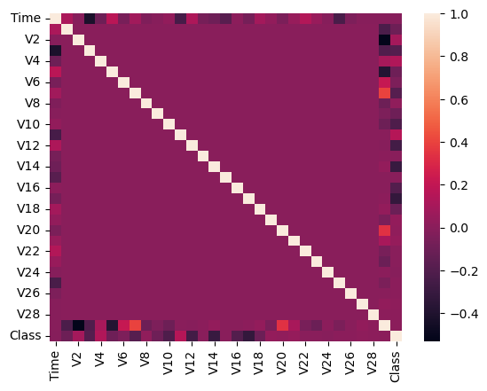

```python
sns.heatmap(corr)
```

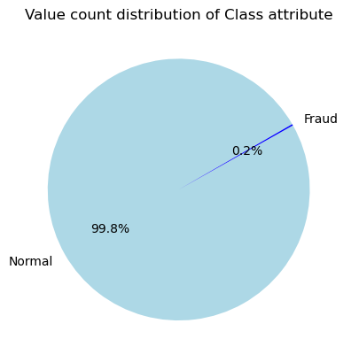

```python
# Get value counts for stroke column
counts = data['Class'].value_counts()

# Set custom labels for pie chart
labels = ['Normal', 'Fraud']

# Create pie chart with custom colors and labels
colors = ['lightblue', 'Blue']
plt.pie(counts, colors=colors, labels=labels, autopct='%1.1f%%', startangle=30)

# Add plot title
plt.title("Value count distribution of Class attribute")

# Show plot
plt.show()
```

This visualization of Class attribute tells that there only 0.2 percent of fraud transactions are made and rest of the data is normal transaction before the sampling the data.

#### After balancing the Class attribute we get following result

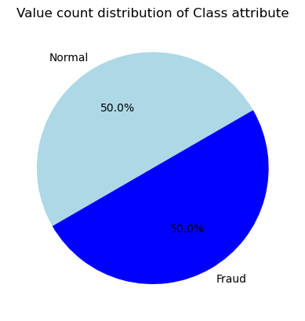

```python
# Get value counts for stroke column
counts = new_data['Class'].value_counts()

# Set custom labels for pie chart
labels = ['Normal', 'Fraud']

# Create pie chart with custom colors and labels
colors = ['lightblue', 'Blue']
plt.pie(counts, colors=colors, labels=labels, autopct='%1.1f%%', startangle=30)

# Add plot title
plt.title("Value count distribution of Class attribute")

# Show plot
plt.show()
```

This visualzation tells that the data is equally distributed after sampling the class attribute.

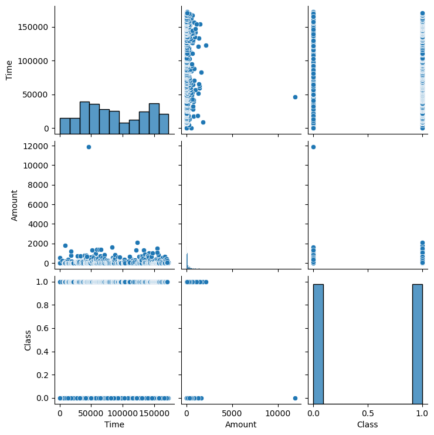

```python
plt.figure()
sns.pairplot(new_data, vars=['Time', 'Amount', 'Class'], markers=["o", "s"])
plt.show()
```

In the observation of pairplot we can say that the graph between amount and time the transaction of amount is very less or the amount is very less.

In between class and time we can say that In a given time transaction of normal and fraud was happened.

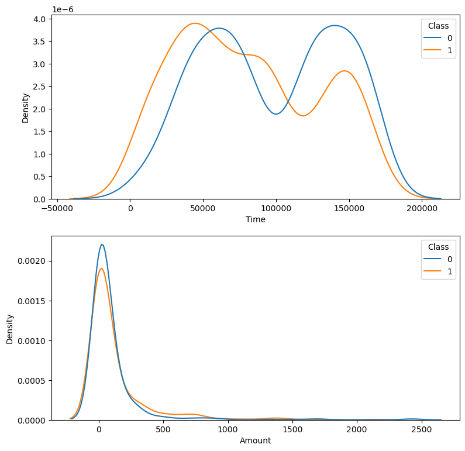

```python
plt.figure(figsize=(9,9))
plt.subplot(2,1,1)
sns.kdeplot(data=new_data, x = "Time", hue ="Class")
plt.subplot(2,1,2)
sns.kdeplot(data=new_data, x = "Amount",hue="Class")
```

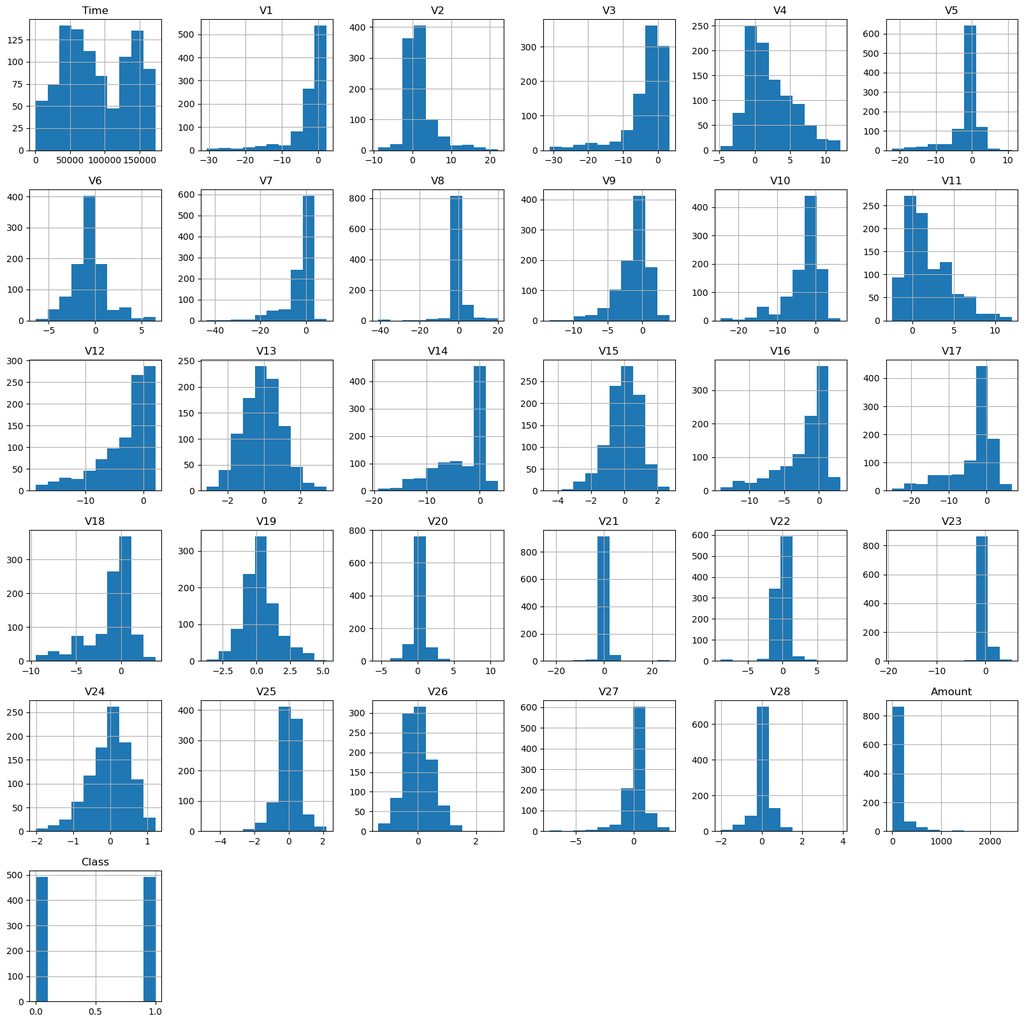

```python
new_data.hist(figsize=(20,20))
plt.show()
```

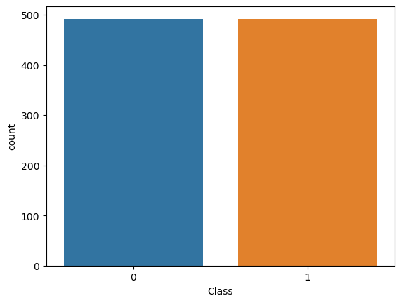

```python
sns.countplot(x ='Class', data = new_data)
```

In this count plot we can observe that the data of Class are equally distributed.

```python
sns.stripplot(x="Amount", y="Class", data=data)
```

[output not shown]

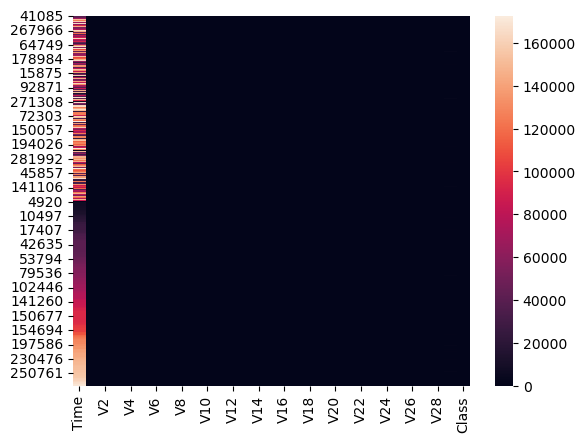

```python
sns.heatmap(new_data)
```

## divide the data into dependent and independent variable

### seperating the dependant and independent variable

Here the independent variable is Time v1-v28, Amount and droped the column Class because this is the target variable

```python
x = new_data.drop(columns = "Class", axis = 1)
x
```

|  | Time | V1 | V2 | V3 | V4 | V5 | V6 | V7 | V8 | V9 | ... | V20 | V21 | V22 | V23 | V24 | V25 | V26 | V27 | V28 | Amount |
| --- | --- | --- | --- | --- | --- | --- | --- | --- | --- | --- | --- | --- | --- | --- | --- | --- | --- | --- | --- | --- | --- |
| 145680 | 87125.0 | -1.103340 | 0.702394 | -1.100975 | -2.494209 | 1.103053 | -2.097877 | 1.608394 | -0.421520 | 0.913303 | ... | -0.154945 | -0.002806 | 0.787495 | 0.070577 | -0.028882 | -0.200344 | 0.518187 | 0.190252 | -0.199114 | 1.00 |
| 60971 | 49589.0 | 1.223422 | 0.309144 | 0.727424 | 1.110498 | -0.505360 | -0.750576 | -0.054292 | -0.137881 | 0.139040 | ... | -0.115423 | -0.075431 | -0.168895 | 0.028876 | 0.374569 | 0.434326 | -0.495462 | 0.038642 | 0.031752 | 1.00 |
| 268933 | 163454.0 | -1.649103 | 1.567169 | -1.588127 | -0.357308 | 0.074773 | -1.626656 | 0.381221 | 0.495446 | -0.198530 | ... | -0.744743 | 0.416295 | 1.260807 | 0.213770 | -0.002556 | -0.708195 | -0.369980 | -0.679177 | -0.201218 | 29.00 |
| 131611 | 79666.0 | 1.243429 | 0.132585 | -0.158441 | -0.022295 | 0.000163 | -0.959618 | 0.466414 | -0.373753 | -0.246144 | ... | 0.132804 | -0.433325 | -1.344319 | 0.082412 | -0.092016 | 0.200669 | 0.645422 | -0.102101 | 0.009956 | 56.94 |
| 150900 | 94094.0 | -0.476083 | 1.773989 | 2.127627 | 4.507577 | -0.224429 | 1.529165 | -0.698580 | 0.783828 | -0.534456 | ... | 0.252764 | -0.004039 | 0.414630 | -0.007649 | -0.385324 | -0.855408 | 0.207048 | 0.360077 | 0.191967 | 0.00 |
| ... | ... | ... | ... | ... | ... | ... | ... | ... | ... | ... | ... | ... | ... | ... | ... | ... | ... | ... | ... | ... | ... |
| 279863 | 169142.0 | -1.927883 | 1.125653 | -4.518331 | 1.749293 | -1.566487 | -2.010494 | -0.882850 | 0.697211 | -2.064945 | ... | 1.252967 | 0.778584 | -0.319189 | 0.639419 | -0.294885 | 0.537503 | 0.788395 | 0.292680 | 0.147968 | 390.00 |
| 280143 | 169347.0 | 1.378559 | 1.289381 | -5.004247 | 1.411850 | 0.442581 | -1.326536 | -1.413170 | 0.248525 | -1.127396 | ... | 0.226138 | 0.370612 | 0.028234 | -0.145640 | -0.081049 | 0.521875 | 0.739467 | 0.389152 | 0.186637 | 0.76 |
| 280149 | 169351.0 | -0.676143 | 1.126366 | -2.213700 | 0.468308 | -1.120541 | -0.003346 | -2.234739 | 1.210158 | -0.652250 | ... | 0.247968 | 0.751826 | 0.834108 | 0.190944 | 0.032070 | -0.739695 | 0.471111 | 0.385107 | 0.194361 | 77.89 |
| 281144 | 169966.0 | -3.113832 | 0.585864 | -5.399730 | 1.817092 | -0.840618 | -2.943548 | -2.208002 | 1.058733 | -1.632333 | ... | 0.306271 | 0.583276 | -0.269209 | -0.456108 | -0.183659 | -0.328168 | 0.606116 | 0.884876 | -0.253700 | 245.00 |
| 281674 | 170348.0 | 1.991976 | 0.158476 | -2.583441 | 0.408670 | 1.151147 | -0.096695 | 0.223050 | -0.068384 | 0.577829 | ... | -0.017652 | -0.164350 | -0.295135 | -0.072173 | -0.450261 | 0.313267 | -0.289617 | 0.002988 | -0.015309 | 42.53 |

984 rows × 30 columns

Get the target variable as Class column which is in categorical type where 0 - Normal transactions 1- Fraud transaction

```python
from sklearn.preprocessing import StandardScaler

# Create a StandardScaler instance
scaler = StandardScaler()

# Fit the scaler to your data and transform the data
X = scaler.fit_transform(x)
```

In above operation, the use of standard scaler is to put the values of independent variables in a particular range.

```python
#dependent variable
y = new_data["Class"]
y
```

```
145680    0
60971     0
268933    0
131611    0
150900    0
         ..
279863    1
280143    1
280149    1
281144    1
281674    1
Name: Class, Length: 984, dtype: int64
```

## LogisticRegression model 1

# train test split

Train test split is used to sperate the training and testing dataset.

Where training data is used to fit the model and testing data is used to prediction.

```python
#splitting the dependent and independent variables into training and testing set
xtrain, xtest, ytrain, ytest = train_test_split(X, y, test_size = 0.2, random_state = 2)
```

```python
print(xtrain.shape,xtest.shape,ytrain.shape, ytest.shape)
```

```
(787, 30) (197, 30) (787,) (197,)
```

```python
from sklearn.linear_model import LogisticRegression
LR = LogisticRegression()
```

```python
LR.fit(xtrain,ytrain)
```

```
LogisticRegression()
```

### model evaluation

```
Model Accuracy: 0.95
Model Precision: 0.99
Model Recall: 0.92
Model F1-Score: 0.95

              precision    recall  f1-score   support

       Valid       0.92      0.99      0.95        95
       Fraud       0.99      0.92      0.95       102

    accuracy                           0.95       197
   macro avg       0.96      0.96      0.95       197
weighted avg       0.96      0.95      0.95       197
```

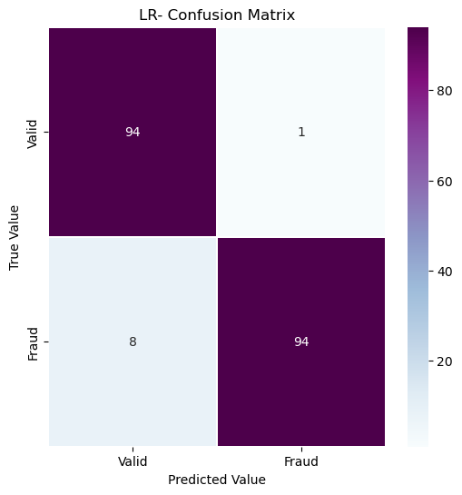

```python
ypred = LR.predict(xtest)
testacc = accuracy_score(ypred, ytest)

print("Model Accuracy:", round(accuracy_score(ytest, ypred),2))
print("Model Precision:", round(precision_score(ytest, ypred),2))
print("Model Recall:", round(recall_score(ytest, ypred),2))
print("Model F1-Score:", round(f1_score(ytest, ypred),2) , '\n')
conf_matrix1 = confusion_matrix(ytest, ypred)
plt.figure(figsize=(6, 6))
labels= ['Valid', 'Fraud']

sns.heatmap(pd.DataFrame(conf_matrix1),annot=True, fmt='d',
            linewidths= 0.05 ,cmap='BuPu',xticklabels= labels, yticklabels= labels)

print(classification_report(ytest, ypred, target_names=labels) , '\n')

plt.title('LR- Confusion Matrix')
plt.ylabel('True Value')
plt.xlabel('Predicted Value')
plt.show()
```

## Random forest classifier: model2

Random Forest is a classifier that contains a number of decision trees on various subsets of the given dataset and takes the average to improve the predictive accuracy of that dataset. It is a supervised learning algorithm It is used for both classification and regression tasks.

```python
#splitting the dependent and independent variables into training and testing set
xtrain, xtest, ytrain, ytest = train_test_split(X, y, test_size = 0.2, random_state = 2)
```

```python
from sklearn.ensemble import RandomForestClassifier
```

```python
RF = RandomForestClassifier()
RF.fit(xtrain, ytrain)
```

```
RandomForestClassifier()
```

```python
ypred1 = RF.predict(xtest)
```

```
Model Accuracy: 95.0
Model Precision: 1.0
Model Recall: 0.9
Model F1-Score: 0.95

              precision    recall  f1-score   support

       Valid       0.90      1.00      0.95        95
       Fraud       1.00      0.90      0.95       102

    accuracy                           0.95       197
   macro avg       0.95      0.95      0.95       197
weighted avg       0.95      0.95      0.95       197
```

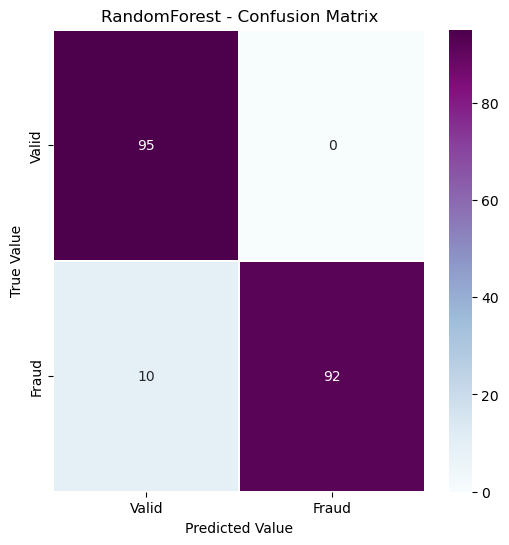

```python
print("Model Accuracy:", round(accuracy_score(ytest, ypred1),2)*100)
print("Model Precision:", round(precision_score(ytest, ypred1),2))
print("Model Recall:", round(recall_score(ytest, ypred1),2))
print("Model F1-Score:", round(f1_score(ytest, ypred1),2) , '\n')
conf_matrix2 = confusion_matrix(ytest, ypred1)
plt.figure(figsize=(6, 6))
labels= ['Valid', 'Fraud']

sns.heatmap(pd.DataFrame(conf_matrix2),annot=True, fmt='d',
            linewidths= 0.05 ,cmap='BuPu',xticklabels= labels, yticklabels= labels)

print(classification_report(ytest, ypred1, target_names=labels) , '\n')

plt.title('RandomForest - Confusion Matrix')
plt.ylabel('True Value')
plt.xlabel('Predicted Value')
plt.show()
```

Random Forest Classifier model is supervised machine learning model which is mostly used for classification. This model created using python is Random forest classifier, the model managed to score and accuracy of 95% using python with 10 misclassified instances.

A decision tree is a non-parametric supervised learning algorithm and it is non parametric.

Used for both classification and regression tasks.

It has a hierarchical, tree structure, which consists of a root node, branches, internal nodes and leaf nodes.

```python
#splitting the dependent and independent variables into training and testing set
xtrain, xtest, ytrain, ytest = train_test_split(x, y, test_size = 0.2, random_state = 2)
```

```python
from sklearn.tree import DecisionTreeClassifier
```

```python
DT = DecisionTreeClassifier()
```

```python
DT.fit(xtrain,ytrain)
```

```
DecisionTreeClassifier()
```

```python
ypred2 = DT.predict(xtest)
```

```
Model Accuracy: 94.0
Model Precision: 0.96
Model Recall: 0.92
Model F1-Score: 0.94

              precision    recall  f1-score   support

       Valid       0.92      0.96      0.94        95
       Fraud       0.96      0.92      0.94       102

    accuracy                           0.94       197
   macro avg       0.94      0.94      0.94       197
weighted avg       0.94      0.94      0.94       197
```

[figure not shown]

```python
print("Model Accuracy:", round(accuracy_score(ytest, ypred2),2)*100)
print("Model Precision:", round(precision_score(ytest, ypred2),2))
print("Model Recall:", round(recall_score(ytest, ypred2),2))
print("Model F1-Score:", round(f1_score(ytest, ypred2),2) , '\n')
conf_matrix1 = confusion_matrix(ytest, ypred7)
plt.figure(figsize=(6, 6))
labels= ['Valid', 'Fraud']

sns.heatmap(pd.DataFrame(conf_matrix1),annot=True, fmt='d',
            linewidths= 0.05 ,cmap='BuPu',xticklabels= labels, yticklabels= labels)

print(classification_report(ytest, ypred2, target_names=labels) , '\n')

plt.title('Decision tree classifier - Confusion Matrix')
plt.ylabel('True Value')
plt.xlabel('Predicted Value')
plt.show()
```

## Kth nearest neighobur model 4

```python
#splitting the dependent and independent variables into training and testing set
xtrain, xtest, ytrain, ytest = train_test_split(X, y, test_size = 0.2, random_state = 2)
```

```python
#Fitting K-NN classifier to the training set
from sklearn.neighbors import KNeighborsClassifier
classifier= KNeighborsClassifier(n_neighbors=7, metric='minkowski', p=2 )
classifier.fit(xtrain, ytrain)
```

```
KNeighborsClassifier(n_neighbors=7)
```

```python
ypred5 = classifier.predict(xtest)
```

```
Model Accuracy: 91.0
Model Precision: 0.98
Model Recall: 0.85
Model F1-Score: 0.91

              precision    recall  f1-score   support

       Valid       0.86      0.98      0.92        95
       Fraud       0.98      0.85      0.91       102

    accuracy                           0.91       197
   macro avg       0.92      0.92      0.91       197
weighted avg       0.92      0.91      0.91       197
```

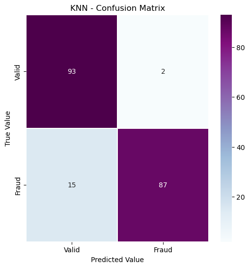

```python
print("Model Accuracy:", round(accuracy_score(ytest, ypred5),2)*100)
print("Model Precision:", round(precision_score(ytest, ypred5),2))
print("Model Recall:", round(recall_score(ytest, ypred5),2))
print("Model F1-Score:", round(f1_score(ytest, ypred5),2) , '\n')
conf_matrix4 = confusion_matrix(ytest, ypred5)
plt.figure(figsize=(6, 6))
labels= ['Valid', 'Fraud']

sns.heatmap(pd.DataFrame(conf_matrix4),annot=True, fmt='d',
            linewidths= 0.05 ,cmap='BuPu',xticklabels= labels, yticklabels= labels)

print(classification_report(ytest, ypred5, target_names=labels) , '\n')

plt.title('KNN - Confusion Matrix')
plt.ylabel('True Value')
plt.xlabel('Predicted Value')
plt.show()
```

## support vector machine model 5

```python
#splitting the dependent and independent variables into training and testing set
xtrain, xtest, ytrain, ytest = train_test_split(X, y, test_size = 0.2, random_state = 2)
```

```python
from sklearn.svm import SVC # "Support vector classifier"
classifier2 = SVC(kernel='linear', random_state=0)
classifier2.fit(xtrain, ytrain)
```

```
SVC(kernel='linear', random_state=0)
```

```python
ypred6 = classifier2.predict(xtest)
```

```
Model Accuracy: 94.0
Model Precision: 0.98
Model Recall: 0.91
Model F1-Score: 0.94

              precision    recall  f1-score   support

       Valid       0.91      0.98      0.94        95
       Fraud       0.98      0.91      0.94       102

    accuracy                           0.94       197
   macro avg       0.95      0.95      0.94       197
weighted avg       0.95      0.94      0.94       197
```

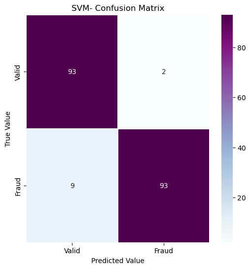

```python
print("Model Accuracy:", round(accuracy_score(ytest, ypred6),2)*100)
print("Model Precision:", round(precision_score(ytest, ypred6),2))
print("Model Recall:", round(recall_score(ytest, ypred6),2))
print("Model F1-Score:", round(f1_score(ytest, ypred6),2) , '\n')
conf_matrix1 = confusion_matrix(ytest, ypred6)
plt.figure(figsize=(6, 6))
labels= ['Valid', 'Fraud']

sns.heatmap(pd.DataFrame(conf_matrix1),annot=True, fmt='d',
            linewidths= 0.05 ,cmap='BuPu',xticklabels= labels, yticklabels= labels)

print(classification_report(ytest, ypred6, target_names=labels) , '\n')

plt.title('SVM- Confusion Matrix')
plt.ylabel('True Value')
plt.xlabel('Predicted Value')
plt.show()
```

## Naive bayes -model 6

Naive Bayes is a family of probabilistic machine learning algorithms based on Bayes' theorem, with a "naive" assumption of independence among the features. Despite its simplicity and the independence assumption (which often doesn't hold in real-world data), Naive Bayes classifiers are remarkably effective in various classification tasks, including text classification, spam email detection, sentiment analysis.

```python
#splitting the dependent and independent variables into training and testing set
xtrain, xtest, ytrain, ytest = train_test_split(X, y, test_size = 0.2, random_state = 2)
```

```python
from sklearn.naive_bayes import GaussianNB
classifier3 = GaussianNB()
classifier3.fit(xtrain, ytrain)
```

```
GaussianNB()
```

```python
ypred7 = classifier3.predict(xtest)
```

```
Model Accuracy: 91.0
Model Precision: 0.94
Model Recall: 0.88
Model F1-Score: 0.91

              precision    recall  f1-score   support

       Valid       0.88      0.94      0.91        95
       Fraud       0.94      0.88      0.91       102

    accuracy                           0.91       197
   macro avg       0.91      0.91      0.91       197
weighted avg       0.91      0.91      0.91       197
```

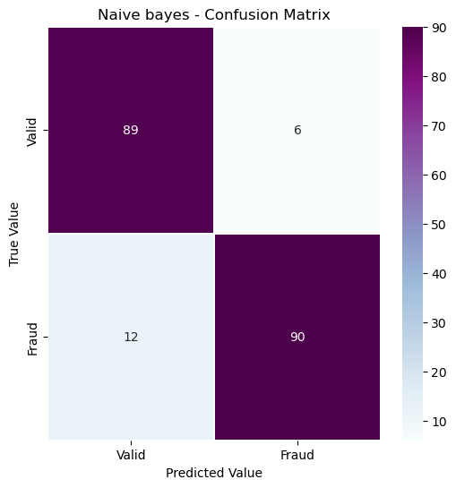

```python
print("Model Accuracy:", round(accuracy_score(ytest, ypred7),2)*100)
print("Model Precision:", round(precision_score(ytest, ypred7),2))
print("Model Recall:", round(recall_score(ytest, ypred7),2))
print("Model F1-Score:", round(f1_score(ytest, ypred7),2) , '\n')
conf_matrix1 = confusion_matrix(ytest, ypred7)
plt.figure(figsize=(6, 6))
labels= ['Valid', 'Fraud']

sns.heatmap(pd.DataFrame(conf_matrix1),annot=True, fmt='d',
            linewidths= 0.05 ,cmap='BuPu',xticklabels= labels, yticklabels= labels)

print(classification_report(ytest, ypred7, target_names=labels) , '\n')

plt.title('Naive bayes - Confusion Matrix')
plt.ylabel('True Value')
plt.xlabel('Predicted Value')
plt.show()
```

In the result naive bayes used for classification problems and it worked well.In the model evaluation of naive bayes we can observed that we get the accuracy of 91% and 18 misclassified instances.